# Social Control - Final Models

Pascal Küng, MSc, Patrick Höhener, MSc, James M. Allen, PhD, Robert Tobias, PhD, Urte Scholz, PhD

2025-08-14

```r
knitr::opts_chunk$set(echo = TRUE)

rm(list = ls())

#cmdstanr::set_cmdstan_path(path = "C:/Users/kueng/.cmdstan/cmdstan-2.35.0")
#cmdstanr::set_cmdstan_path(path = "C:/Users/pascku/.cmdstan/cmdstan-2.36.0")

library(tidyverse)
library(R.utils)
library(wbCorr)
library(readxl)
library(kableExtra)
library(brms)
library(bayesplot)
library(see)
library(beepr)
library(DHARMa)
library(digest)



source(file.path('Functions', 'ReportModels.R'))
source(file.path('Functions', 'PrettyTables.R'))
source(file.path('Functions', 'ReportMeasures.R'))
source(file.path('Functions', 'PrepareData.R'))

report_function_hash <- digest::digest(summarize_brms)
```

```r
system("shutdown /a")
```

```
## [1] 1116
```

```r
# Set options for analysis
use_mi = FALSE
shutdown = FALSE
report_ordinal = FALSE
do_priorsense = FALSE
get_bayesfactor = TRUE
check_models = TRUE

conditional_spaghettsi_plots = FALSE

if (get_bayesfactor) {
  stats_to_report <- c('CI', 'SE', 'pd', 'ROPE', 'BF', 'Rhat', 'ESS')
} else {
  stats_to_report <- c('CI', 'SE', 'pd', 'ROPE', 'Rhat', 'ESS')
}

options(
  dplyr.print_max = 100,
  brms.backend = 'cmdstan',
  brms.file_refit = ifelse(use_mi, 'never', 'on_change'),
  brms.file_refit = 'on_change',
  #brms.file_refit = 'always',
  error = function() {
    beepr::beep(sound = 5)
    if (shutdown) {
      system("shutdown /s /t 180")
      quit(save = "no", status = 1)
    }
  }
  , es.use_symbols = TRUE
)


####################### Model parameters #######################

iterations = 12000 # 12'000 per chain to achieve 40'000
warmup = 2000 # 2000

# NO AR!!!
#corstr = 'ar'
#corstr = 'cosy_couple'
#corstr = 'cosy_couple:user'


################################################################

suffix = paste0('_MainModels', as.character(iterations))
```

```r
df <- openxlsx::read.xlsx(file.path('long.xlsx'))
df_original <- df

df_double <- prepare_data(df, recode_pushing = TRUE, use_mi = use_mi)[[1]]
```

Constructing scales Re-coding pusing reshaping data (4field) centering data within and between

```r
summary(df_double$pushing)
```

Min. 1st Qu. Median Mean 3rd Qu. Max. NA’s 0.0000 0.0000 0.0000 0.1649 0.0000 5.0000 275

# Prepare stuff

```r
df2 <- df_double %>%
  rename(
    received_persuasion_self = persuasion_self,
    received_persuasion_partner = persuasion_partner,
    received_persuasion_self_cw = persuasion_self_cw,
    received_persuasion_partner_cw = persuasion_partner_cw,
    received_persuasion_self_cb = persuasion_self_cb,
    received_persuasion_partner_cb = persuasion_partner_cb,

    received_pressure_self = pressure_self,
    received_pressure_partner = pressure_partner,
    received_pressure_self_cw = pressure_self_cw,
    received_pressure_partner_cw = pressure_partner_cw,
    received_pressure_self_cb = pressure_self_cb,
    received_pressure_partner_cb = pressure_partner_cb,

    received_pushing_self = pushing_self,
    received_pushing_partner = pushing_partner,
    received_pushing_self_cw = pushing_self_cw,
    received_pushing_partner_cw = pushing_partner_cw,
    received_pushing_self_cb = pushing_self_cb,
    received_pushing_partner_cb = pushing_partner_cb
  )
```

# Correlations between self-report and partner-report

# Method 2

```r
# Truth bias model

formula <- bf(
  received_persuasion_self ~
    day +
    exerted_persuasion_partner_cw +
    exerted_persuasion_self_cw +
    exerted_persuasion_partner_cb +
    exerted_persuasion_self_cb +
    (1 | coupleID)
  + (1 + exerted_persuasion_partner_cw + exerted_persuasion_self_cw | coupleID:userID)
)


fit <- brm(
  formula,
  data = df2,
  chains = 4,
  cores = 4,
  file = 'models_cache_brms/testest'
)
summary(fit)
```

```
##  Family: gaussian
##   Links: mu = identity; sigma = identity
## Formula: received_persuasion_self ~ day + exerted_persuasion_partner_cw + exerted_persuasion_self_cw + exerted_persuasion_partner_cb + exerted_persuasion_self_cb + (1 | coupleID) + (1 + exerted_persuasion_partner_cw + exerted_persuasion_self_cw | coupleID:userID)
##    Data: df2 (Number of observations: 3742)
##   Draws: 4 chains, each with iter = 2000; warmup = 1000; thin = 1;
##          total post-warmup draws = 4000
##
## Multilevel Hyperparameters:
## ~coupleID (Number of levels: 38)
##               Estimate Est.Error l-95% CI u-95% CI Rhat Bulk_ESS Tail_ESS
## sd(Intercept)     0.03      0.02     0.00     0.09 1.00      903     1551
##
## ~coupleID:userID (Number of levels: 76)
##                                                               Estimate
## sd(Intercept)                                                     0.20
## sd(exerted_persuasion_partner_cw)                                 0.25
## sd(exerted_persuasion_self_cw)                                    0.30
## cor(Intercept,exerted_persuasion_partner_cw)                      0.59
## cor(Intercept,exerted_persuasion_self_cw)                         0.50
## cor(exerted_persuasion_partner_cw,exerted_persuasion_self_cw)    -0.20
##                                                               Est.Error
## sd(Intercept)                                                      0.02
## sd(exerted_persuasion_partner_cw)                                  0.03
## sd(exerted_persuasion_self_cw)                                     0.03
## cor(Intercept,exerted_persuasion_partner_cw)                       0.11
## cor(Intercept,exerted_persuasion_self_cw)                          0.12
## cor(exerted_persuasion_partner_cw,exerted_persuasion_self_cw)      0.15
##                                                               l-95% CI u-95% CI
## sd(Intercept)                                                     0.16     0.25
## sd(exerted_persuasion_partner_cw)                                 0.20     0.31
## sd(exerted_persuasion_self_cw)                                    0.25     0.37
## cor(Intercept,exerted_persuasion_partner_cw)                      0.34     0.78
## cor(Intercept,exerted_persuasion_self_cw)                         0.25     0.72
## cor(exerted_persuasion_partner_cw,exerted_persuasion_self_cw)    -0.47     0.10
##                                                               Rhat Bulk_ESS
## sd(Intercept)                                                 1.00     1542
## sd(exerted_persuasion_partner_cw)                             1.00     1006
## sd(exerted_persuasion_self_cw)                                1.00     1510
## cor(Intercept,exerted_persuasion_partner_cw)                  1.01      813
## cor(Intercept,exerted_persuasion_self_cw)                     1.00     1175
```

[output cut: 17 more lines]

```
##                               Bulk_ESS Tail_ESS
## Intercept                         2117     2271
## day                               7503     2756
## exerted_persuasion_partner_cw     1458     2106
## exerted_persuasion_self_cw        1798     2467
## exerted_persuasion_partner_cb     1745     2225
## exerted_persuasion_self_cb        2398     2473
##
## Further Distributional Parameters:
##       Estimate Est.Error l-95% CI u-95% CI Rhat Bulk_ESS Tail_ESS
## sigma     0.74      0.01     0.72     0.76 1.00     6238     2611
##
## Draws were sampled using sample(hmc). For each parameter, Bulk_ESS
## and Tail_ESS are effective sample size measures, and Rhat is the potential
## scale reduction factor on split chains (at convergence, Rhat = 1).
```

```r
cors <- wbCorr(
  df2[,c('exerted_persuasion_self', 'received_persuasion_partner')],
  df2$coupleID,
  method = 'spearman')

summary(cors, 'wb')
```

$merged_wb exerted_persuasion_self received_persuasion_partner exerted_persuasion_self [0.18] 0.42 *received_persuasion_partner 0.80* [0.20]

$note [1] “**p < 0.001,** p < 0.01, p < 0.05”

```r
cors <- wbCorr(
  df2[,c('exerted_pressure_self', 'received_pressure_partner')],
  df2$coupleID,
  method = 'spearman')

summary(cors, 'wb')
```

$merged_wb exerted_pressure_self received_pressure_partner exerted_pressure_self [0.51] 0.44 *received_pressure_partner 0.64* [0.55]

$note [1] “**p < 0.001,** p < 0.01, p < 0.05”

```r
cors <- wbCorr(
  df2[,c('exerted_pushing_self', 'received_pushing_partner')],
  df2$coupleID,
  method = 'spearman')

summary(cors, 'wb')
```

$merged_wb exerted_pushing_self received_pushing_partner exerted_pushing_self [0.17] 0.25 *received_pushing_partner 0.65* [0.08]

$note [1] “**p < 0.001,** p < 0.01, p < 0.05”

# Reliability Omega within-person and between-person

```r
reliability_psc <- multilevelTools::omegaSEM(
  c('exerted_persuasion_self', 'received_persuasion_partner'),
  'coupleID',
  data = df2
)
print(reliability_psc)
```

$Results label est ci.lower ci.upper 20 omega_within 0.480 0.447 0.514 24 omega_between 0.996 0.989 1.003

```r
reliability_nsc <- multilevelTools::omegaSEM(
  c('exerted_pressure_self', 'received_pressure_partner'),
  'coupleID',
  data = df2
)
print(reliability_nsc)
```

$Results label est ci.lower ci.upper 20 omega_within 0.332 0.289 0.374 24 omega_between 0.998 0.996 1.000

```r
reliability_pushing <- multilevelTools::omegaSEM(
  c('exerted_pushing_self', 'received_pushing_partner'),
  'coupleID',
  data = df2
)
print(reliability_pushing)
```

$Results label est ci.lower ci.upper 20 omega_within 0.312 0.243 0.38 24 omega_between 1.000 1.000 1.00

# Modelling

```r
# For indistinguishable Dyads
model_rows_fixed <- c(
    'Intercept',
    # '-- WITHIN PERSON MAIN EFFECTS --',
    'persuasion_self_cw',
    'persuasion_partner_cw',
    'pressure_self_cw',
    'pressure_partner_cw',
    'pushing_self_cw',
    'pushing_partner_cw',
    'day',
    'plan_selfPlan',
    'plan_partnerPlan',
    'weartime_self_cw',

    # '-- BETWEEN PERSON MAIN EFFECTS',
    'persuasion_self_cb',
    'persuasion_partner_cb',
    'pressure_self_cb',
    'pressure_partner_cb',
    'pushing_self_cb',
    'pushing_partner_cb',
    'weartime_self_cb'
  )


model_rows_fixed_ordinal <- c(
  model_rows_fixed[1],
  'Intercept[1]',
  'Intercept[2]',
  'Intercept[3]',
  'Intercept[4]',
  'Intercept[5]',
  model_rows_fixed[2:length(model_rows_fixed)]
)

model_rows_random <- c(
  # '--------------',
  # '-- RANDOM EFFECTS --',
  'coupleID: sd(Intercept)',

  'coupleID:userID: sd(Intercept)',
  'coupleID:userID: sd(persuasion_self_cw)',
  'coupleID:userID: sd(persuasion_partner_cw)',
  'coupleID:userID: sd(pressure_self_cw)',
  'coupleID:userID: sd(pressure_partner_cw)',
  'coupleID:userID: sd(pushing_self_cw)',
  'coupleID:userID: sd(pushing_partner_cw)',

  # '-- CORRELATION STRUCTURE -- ',
  'sigma'
)

model_rows_random_ordinal <- c(model_rows_random,'disc')
```

```r
# For indistinguishable Dyads
model_rownames_fixed <- c(
    "Intercept",
    # "-- WITHIN PERSON MAIN EFFECTS --",
    "Daily individual's experienced persuasion",
    "Daily partner's experienced persuasion",
    "Daily individual's experienced pressure",
    "Daily partner's experienced pressure",
    "Daily individual's experienced pushing",
    "Daily partner's experienced pushing",
    "Day",
    "Own action plan",
    'Partner action plan',
    "Daily wear time",

    # "-- BETWEEN PERSON MAIN EFFECTS",
    "Mean individual's experienced persuasion",
    "Mean partner's experienced persuasion",
    "Mean individual's experienced pressure",
    "Mean partner's experienced pressure",
    "Mean individual's experienced pushing",
    "Mean partner's experienced pushing",
    "Mean wear time"
  )


model_rownames_fixed_ordinal <- c(
  model_rownames_fixed[1],
  'Intercept[1]',
  'Intercept[2]',
  'Intercept[3]',
  'Intercept[4]',
  'Intercept[5]',
  model_rownames_fixed[2:length(model_rownames_fixed)]
)


model_rownames_random <- c(
  # '--------------',
  # '-- RANDOM EFFECTS L3 --',
  'L3:sd(Intercept)',


  'L2:sd(Intercept)',
  "L2:sd(Daily individual's experienced persuasion)",
  "L2:sd(Daily partner's experienced persuasion)", # OR partner received
  "L2:sd(Daily individual's experienced pressure)",
  "L2:sd(Daily partner's experienced pressure)",
  "L2:sd(Daily individual's experienced pushing)",
  "L2:sd(Daily partner's experienced pushing)",

  # '-- CORRELATION STRUCTURE L1 -- ',
  'sigma'
)

model_rownames_random_ordinal <- c(model_rownames_random,'disc')
```

```r
rows_to_pack <- list(
  "Within-Person Effects" = c(2,11),
  "Between-Person Effects" = c(12,18),
  "Random Effects (Level 3 - Couple)" = c(19, 19),
  "Random Effects (Level 2 - Couple:Person)" = c(20, 26),
  "Additional Parameters" = c(27,27)
  )


rows_to_pack_ordinal <- list(
  "Within-Person Effects" = c(2+5,11+5),
  "Between-Person Effects" = c(12+5,18+5),
  "Random Effects (Level 3 - Couple)" = c(19+5, 19+5),
  "Random Effects (Level 2 - Couple:Person)" = c(20+5, 26+5),
  "Additional Parameters" = c(27+5,27+6)
  )
```

## Self-Reported MVPA

```r
range(df_double$pa_sub, na.rm = T)
```

```
## [1]   0 720
```

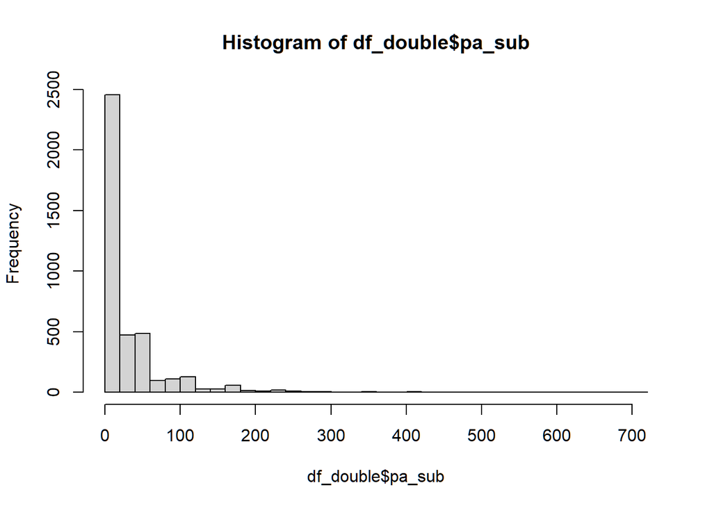

```r
hist(df_double$pa_sub, breaks = 40)
```

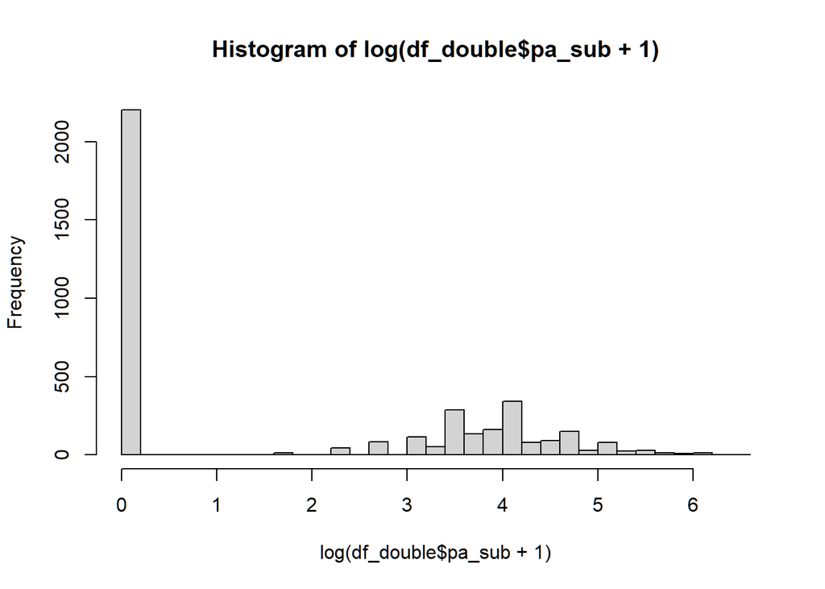

```r
hist(log(df_double$pa_sub+00000000001), breaks = 40)
```

### Hurdle Lognormal Model

```r
formula <- bf(
  pa_sub ~
    persuasion_self_cw + persuasion_partner_cw +
    pressure_self_cw + pressure_partner_cw +
    pushing_self_cw + pushing_partner_cw +

    persuasion_self_cb + persuasion_partner_cb +
    pressure_self_cb + pressure_partner_cb +
    pushing_self_cb + pushing_partner_cb +

    plan_self + plan_partner +
    day +

    # Random effects
    (1 | dd | coupleID)

  + (1 + persuasion_self_cw + persuasion_partner_cw +
    pressure_self_cw + pressure_partner_cw +
    pushing_self_cw + pushing_partner_cw | d_u | coupleID:userID),

  hu = ~ persuasion_self_cw + persuasion_partner_cw +
    pressure_self_cw + pressure_partner_cw +
    pushing_self_cw + pushing_partner_cw +

    persuasion_self_cb + persuasion_partner_cb +
    pressure_self_cb + pressure_partner_cb +
    pushing_self_cb + pushing_partner_cb +

    plan_self + plan_partner +
    day +

    # Random effects
    (1 | dd | coupleID)

  + (1 + persuasion_self_cw + persuasion_partner_cw +
    pressure_self_cw + pressure_partner_cw +
    pushing_self_cw + pushing_partner_cw | d_u | coupleID:userID)

  , decomp = 'QR'
  #, autocor = autocor_str
)

prior1 <- c(
  brms::set_prior("normal(0, 2.5)", class = "b")
  , brms::set_prior("normal(0, 2)", class = "b", dpar = "hu")
  , brms::set_prior("normal(0, 50)", class = "Intercept") # for non-zero PA
  , brms::set_prior("normal(0.5, 2.5)", class = "Intercept", dpar = 'hu') # hurdle part
  , brms::set_prior("normal(0, 2)", class = "sd", group = "coupleID", lb = 0)
  , brms::set_prior("student_t(3, 0, 2.5)", class = "sigma", lb = 0)
)

#brms::validate_prior(
#  prior1,
#  formula = formula,
#  data = df_double,
#  family = hurdle_lognormal()
#)

#df_minimal <- df_double[, c("AorB", all.vars(as.formula(formula)))]

pa_sub <- my_brm(
  mi = use_mi,
  imputed_data = implist,

  formula = formula,
  prior = prior1,
  data = df_double,
  family = brms::hurdle_lognormal(),
  #family = brms::hurdle_negbinomial(),
  #family = brms::hurdle_poisson(),
  #control = list(adapt_delta = 0.95, max_treedepth = 15),
  iter = iterations,
  warmup = warmup,
  chains = 4,
  cores = 4,
  seed = 42,
  file = file.path("models_cache_brms", paste0("pa_sub_hu_lognormal", suffix))
  #, file_refit = 'always'
)
pa_sub_digest <- digest::digest(pa_sub)
```

```r
if (check_models) {
  check_brms(pa_sub, log_pp_check = TRUE)
  DHARMa.check_brms.all(pa_sub, integer = TRUE, outliers_type = 'bootstrap')
}
```

```
## # Check for Multicollinearity
##
## Low Correlation
##
##                   Term  VIF   VIF 95% CI Increased SE Tolerance
##     persuasion_self_cw 1.54 [1.50, 1.58]         1.24      0.65
##  persuasion_partner_cw 1.08 [1.06, 1.11]         1.04      0.92
##       pressure_self_cw 1.07 [1.05, 1.10]         1.04      0.93
##    pressure_partner_cw 1.04 [1.03, 1.07]         1.02      0.96
##        pushing_self_cw 1.03 [1.01, 1.06]         1.01      0.97
##     pushing_partner_cw 1.05 [1.04, 1.08]         1.03      0.95
##     persuasion_self_cb 1.06 [1.04, 1.09]         1.03      0.94
##  persuasion_partner_cb 2.38 [2.30, 2.46]         1.54      0.42
##       pressure_self_cb 2.35 [2.27, 2.43]         1.53      0.43
##    pressure_partner_cb 1.86 [1.81, 1.92]         1.36      0.54
##        pushing_self_cb 1.90 [1.84, 1.96]         1.38      0.53
##     pushing_partner_cb 2.29 [2.21, 2.36]         1.51      0.44
##              plan_self 2.27 [2.20, 2.34]         1.51      0.44
##           plan_partner 1.36 [1.32, 1.40]         1.17      0.74
##                    day 1.33 [1.30, 1.37]         1.15      0.75
##  Tolerance 95% CI
##      [0.63, 0.67]
##      [0.90, 0.94]
##      [0.91, 0.95]
##      [0.93, 0.97]
##      [0.94, 0.99]
##      [0.92, 0.97]
##      [0.92, 0.96]
##      [0.41, 0.43]
##      [0.41, 0.44]
##      [0.52, 0.55]
##      [0.51, 0.54]
##      [0.42, 0.45]
##      [0.43, 0.46]
##      [0.72, 0.76]
##      [0.73, 0.77]
## # Distribution of Model Family
##
## Predicted Distribution of Residuals
##
##  Distribution Probability
##        cauchy        100%
##
## Predicted Distribution of Response
##
##                Distribution Probability
##  neg. binomial (zero-infl.)         78%
##               beta-binomial         16%
##                   lognormal          3%
##
## Divergences:
```

```
## 0 of 40000 iterations ended with a divergence.
```

```
##
## Tree depth:
```

```
## 0 of 40000 iterations saturated the maximum tree depth of 10.
```

```
##
## Energy:
```

```
## E-BFMI indicated no pathological behavior.
```

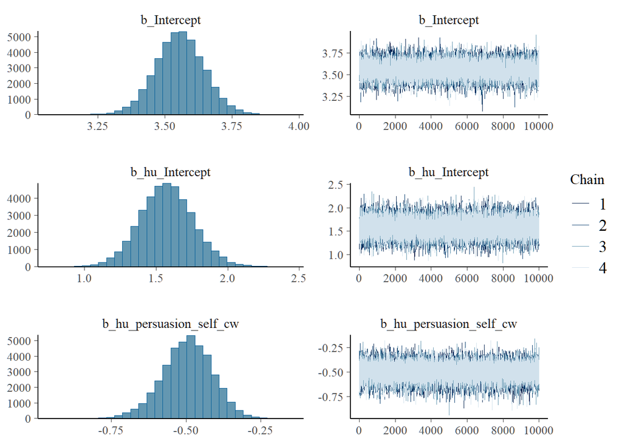

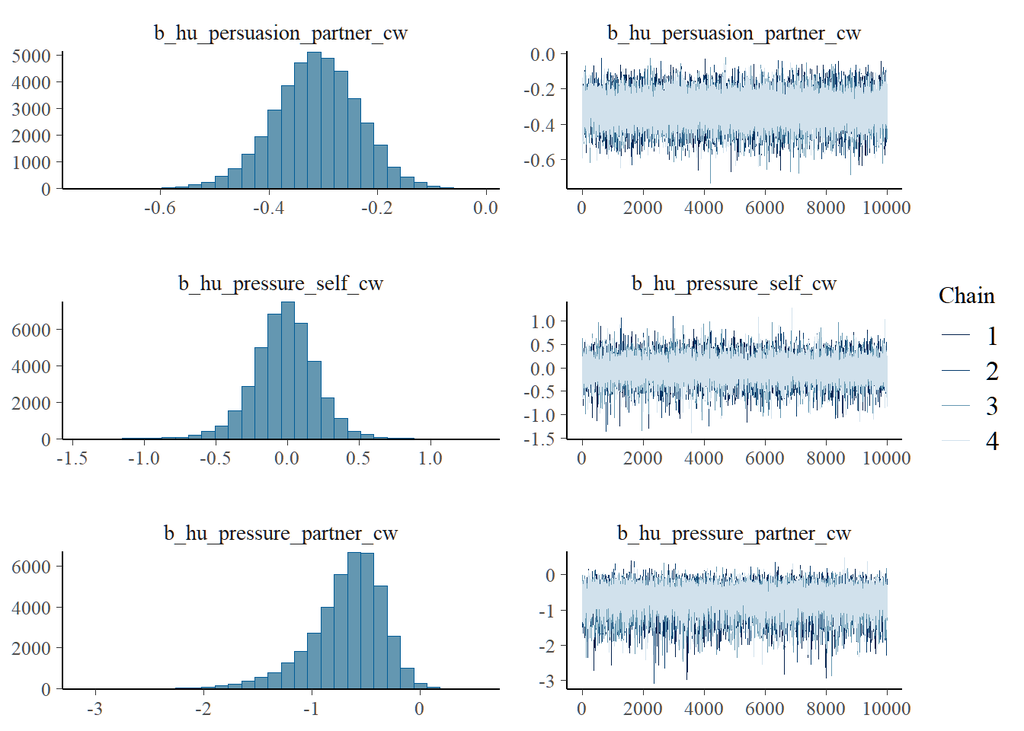

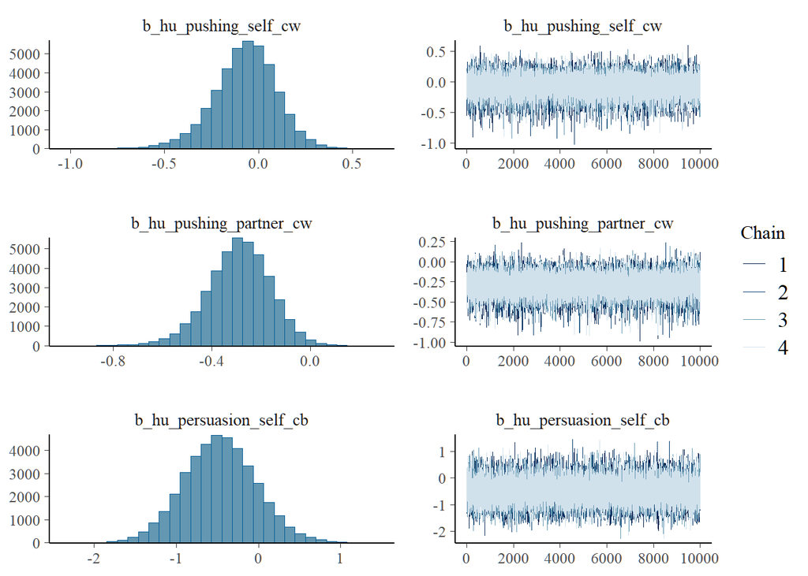

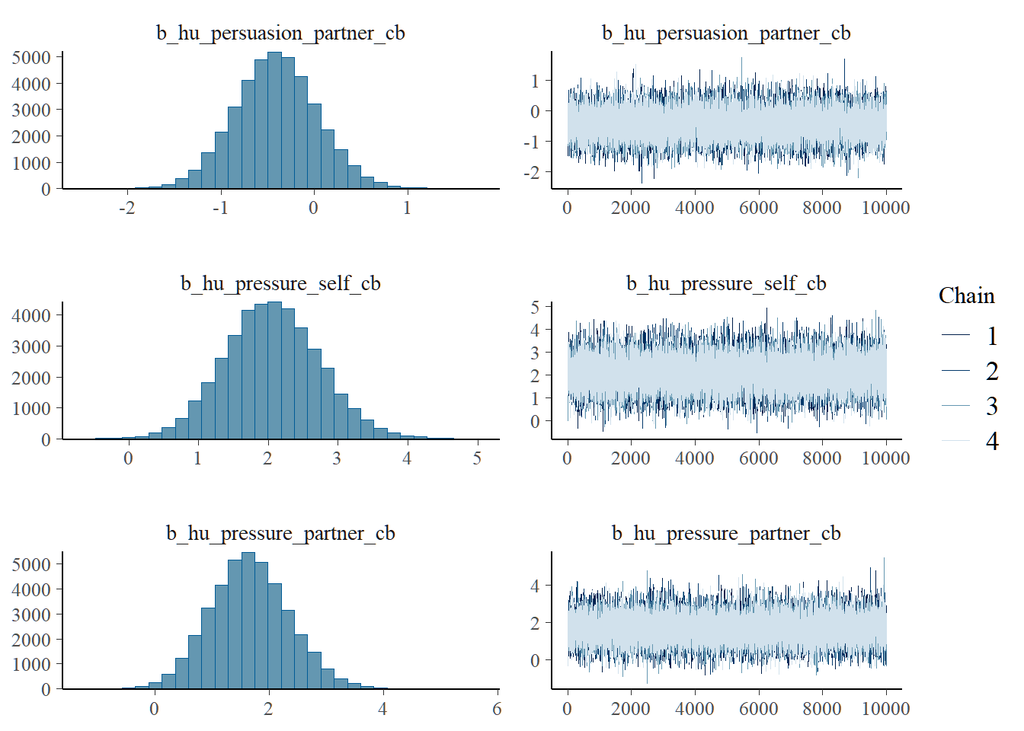

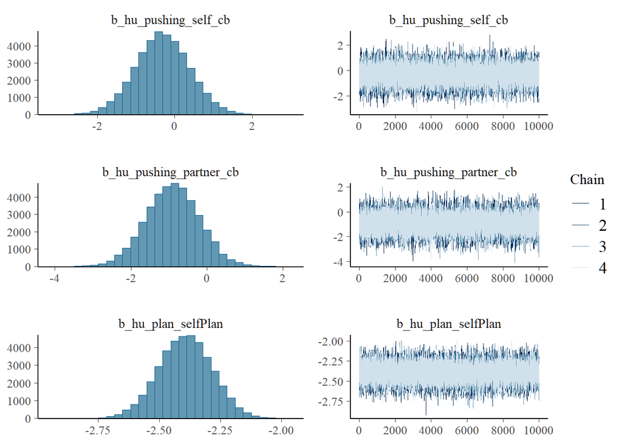

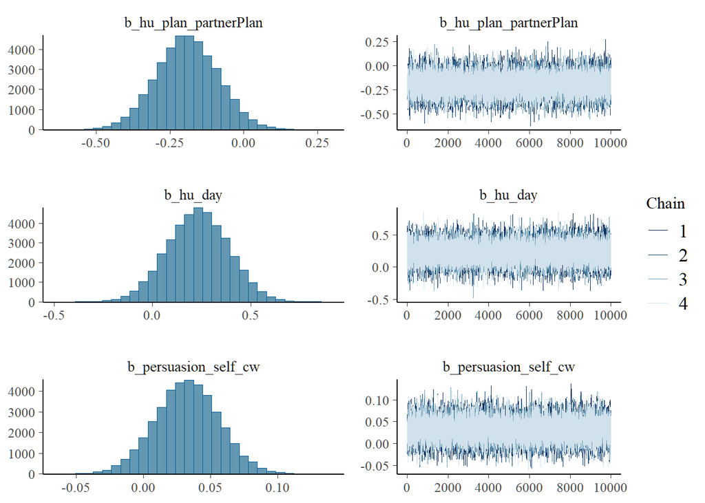

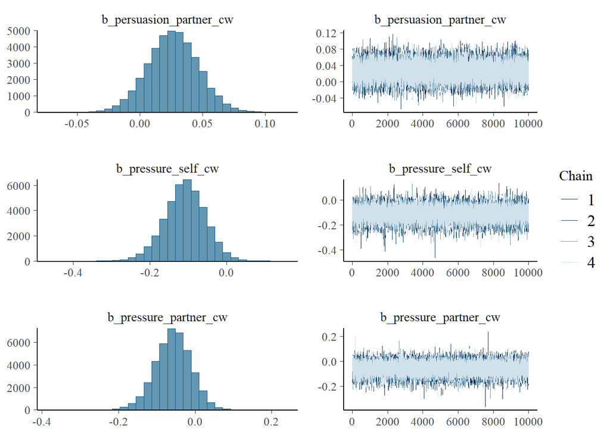

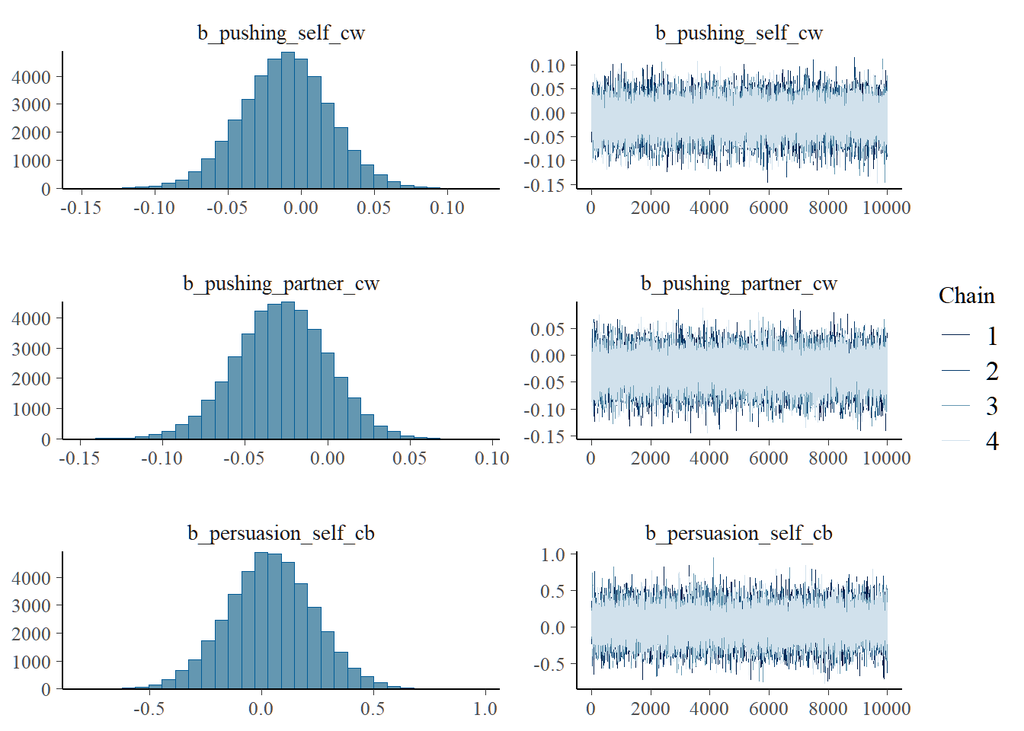

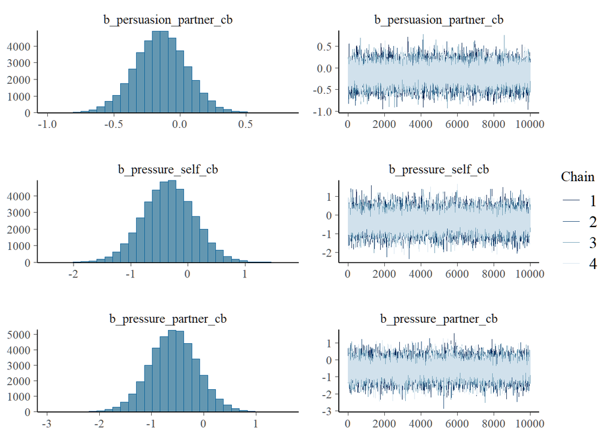

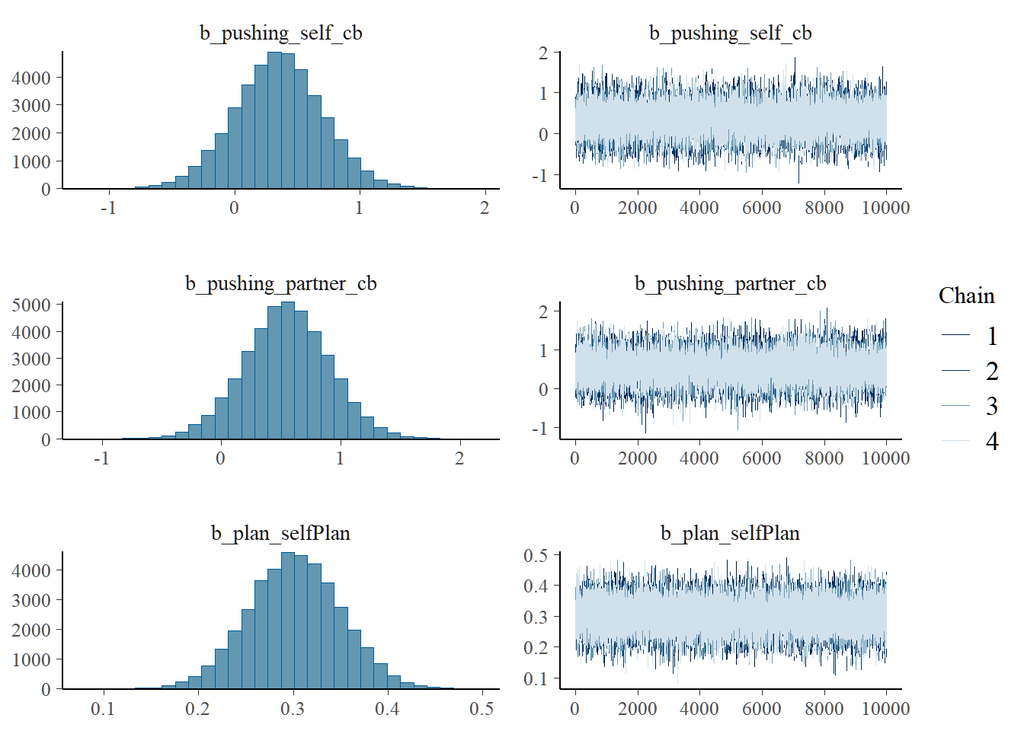

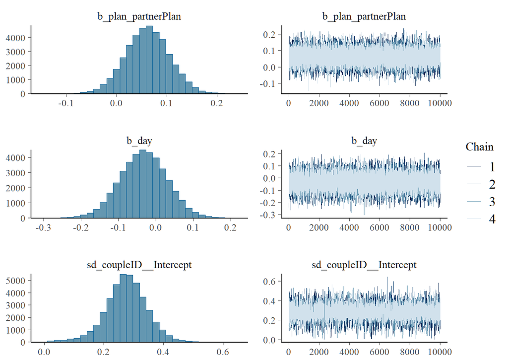

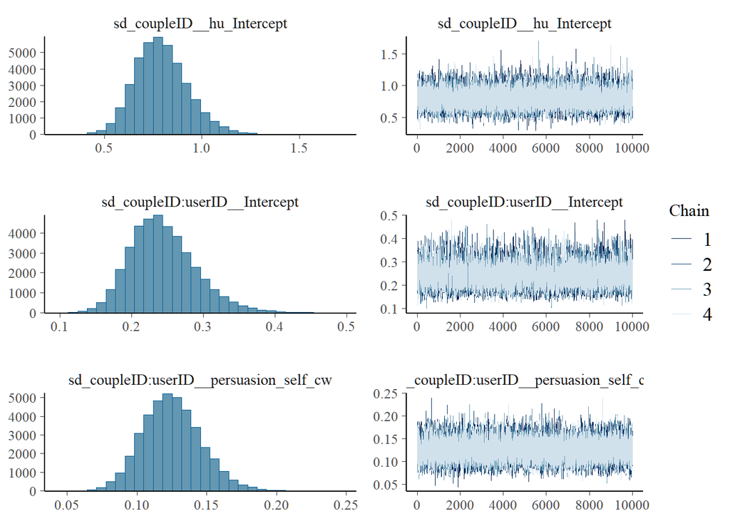

[35 more figures not shown]

```
## Using 10 posterior draws for ppc type 'ecdf_overlay' by default.
```

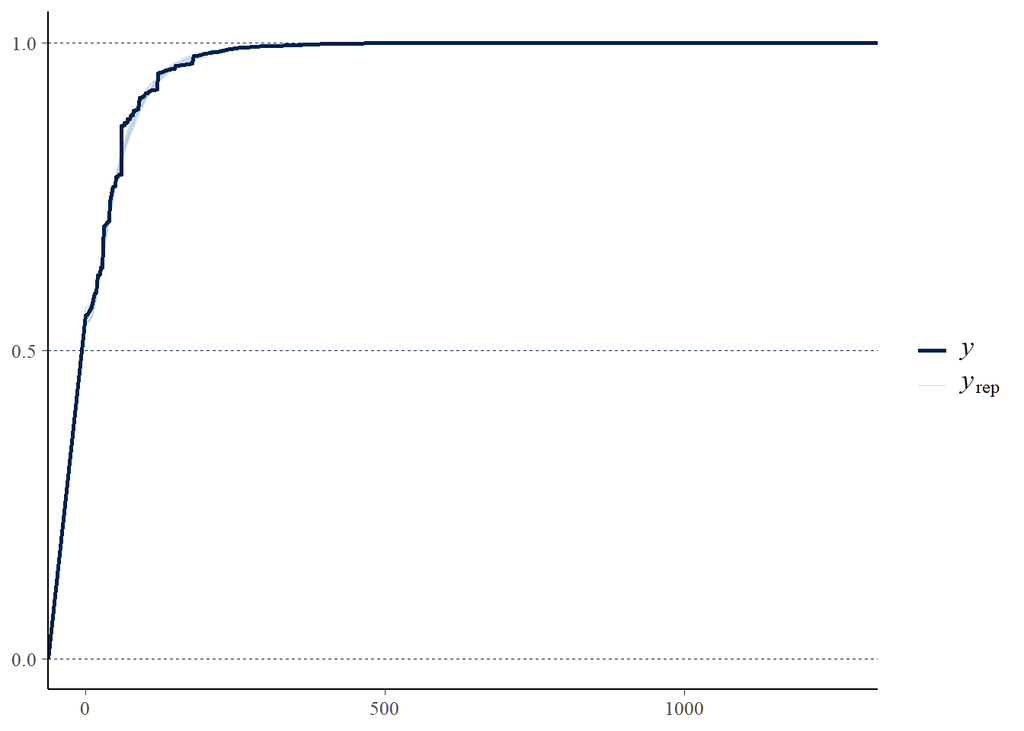

```
## Using 10 posterior draws for ppc type 'dens_overlay' by default.
```

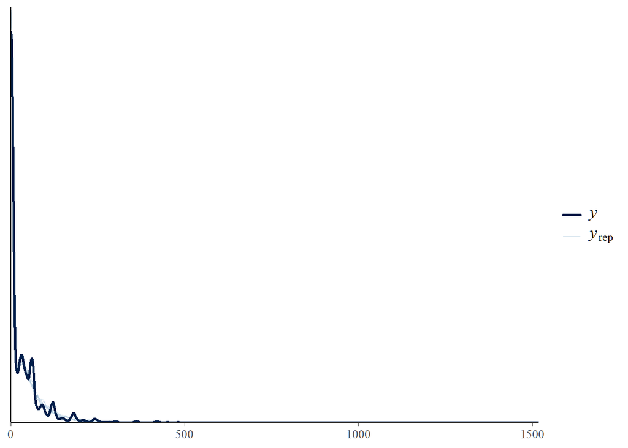

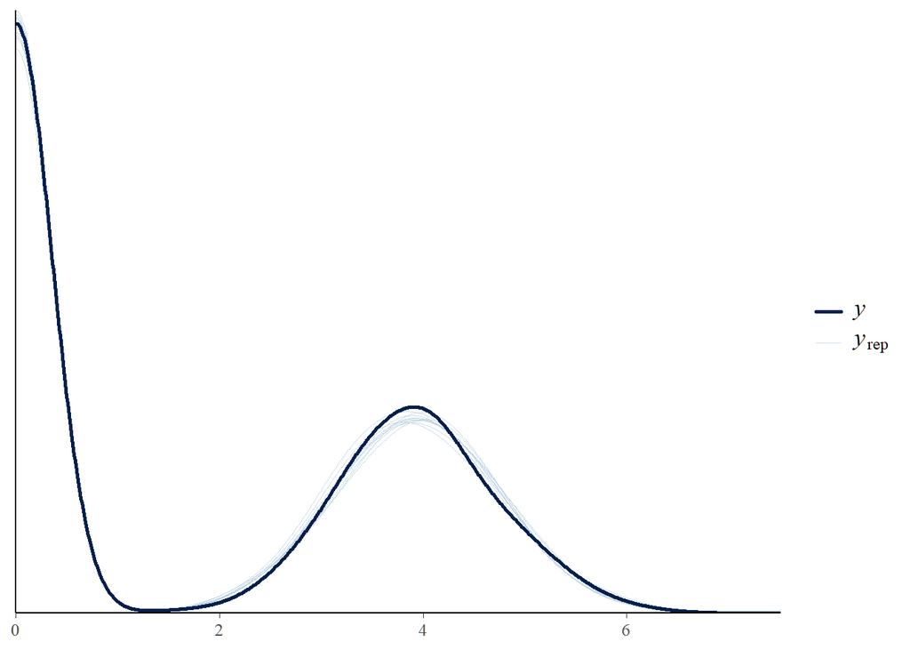

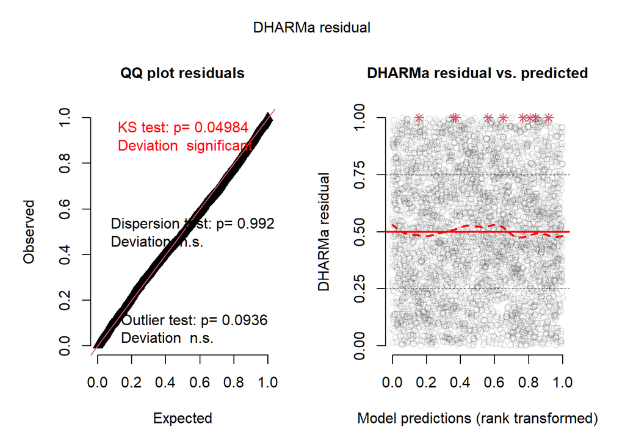

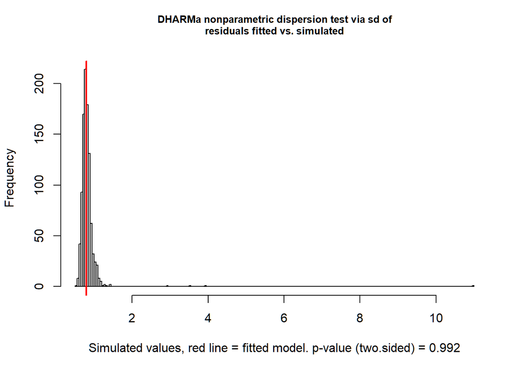

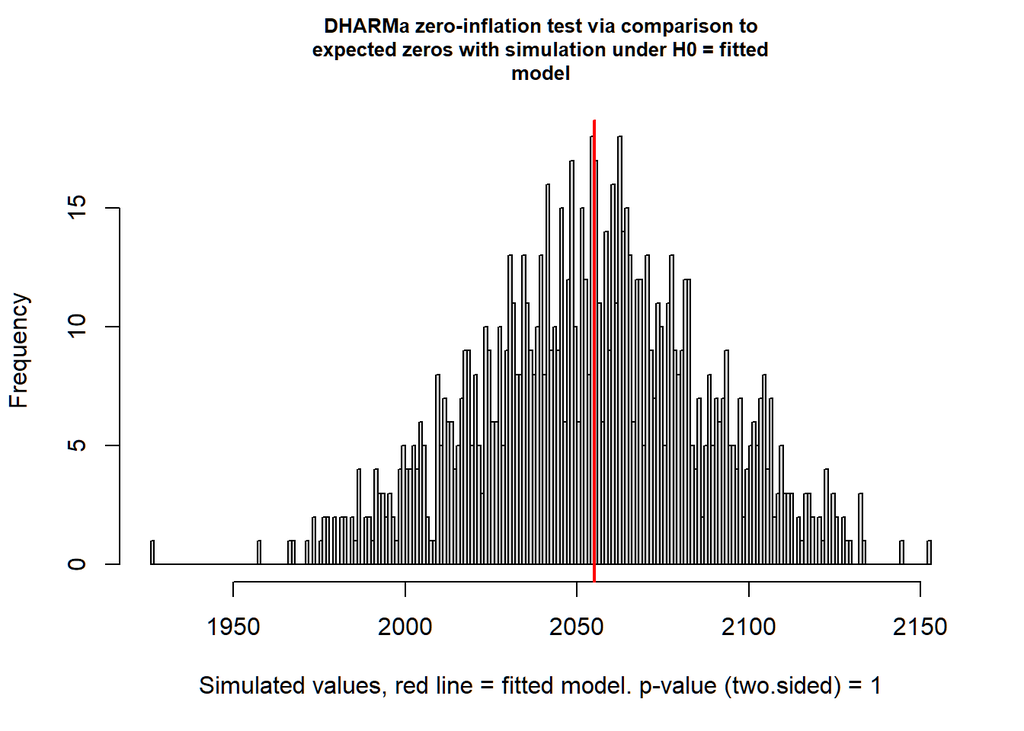

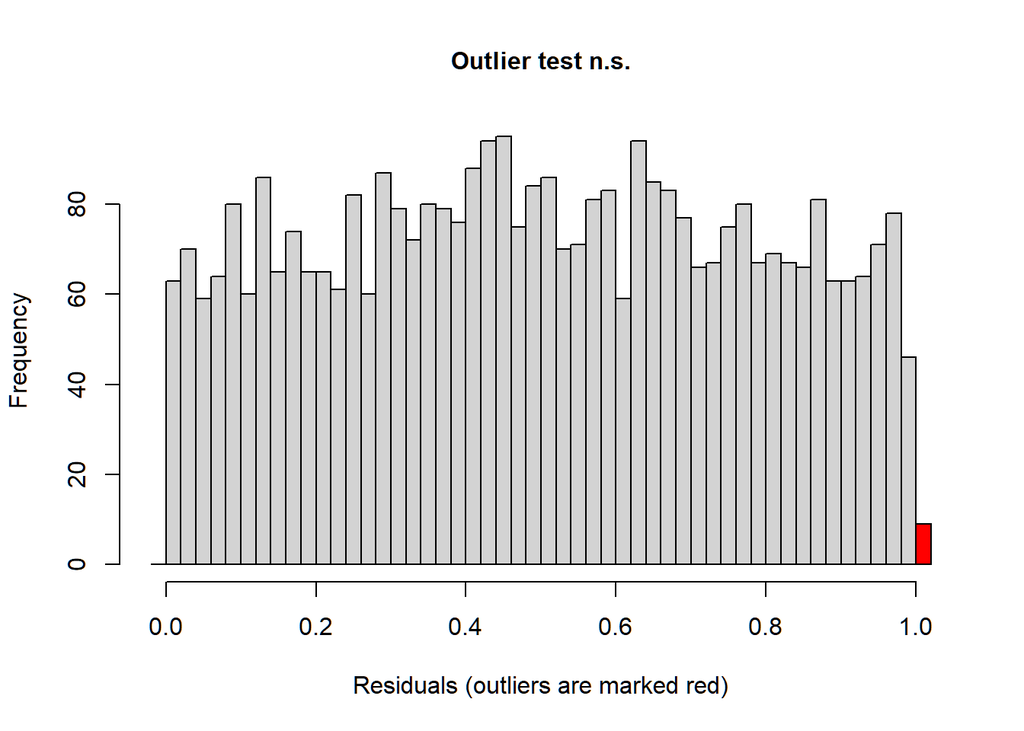

```
##
##  DHARMa bootstrapped outlier test
##
## data:  model.check
## outliers at both margin(s) = 9, observations = 3684, p-value = 0.2
## alternative hypothesis: two.sided
##  percent confidence interval:
##  0.0005428882 0.0031283931
## sample estimates:
## outlier frequency (expected: 0.00154723127035831 )
##                                        0.002442997
```

```r
if (do_priorsense) {
  priorsense_vars <- c(
      'Intercept',
      'b_persuasion_self_cw',
      'b_persuasion_partner_cw',
      'b_pressure_self_cw',
      'b_pressure_partner_cw',
      'b_pushing_self_cw',
      'b_pushing_partner_cw'
  )

  hurdle_priorsense_vars <- c(
    'Intercept_hu',
    'b_hu_persuasion_self_cw',
    'b_hu_persuasion_partner_cw',
    'b_hu_pressure_self_cw',
    'b_hu_pressure_partner_cw',
    'b_hu_pushing_self_cw',
    'b_hu_pushing_partner_cw'
  )

  gc()
  priorsense::powerscale_sensitivity(pa_sub, variable = c(priorsense_vars, hurdle_priorsense_vars))
  priorsense::powerscale_plot_dens(pa_sub, variable = c(priorsense_vars, hurdle_priorsense_vars))
  priorsense::powerscale_plot_ecdf(pa_sub, variable = c(priorsense_vars, hurdle_priorsense_vars))
  priorsense::powerscale_plot_quantities(pa_sub, variable = c(priorsense_vars, hurdle_priorsense_vars))
}
```

```r
# rope range for continuous part of the model
rope_factor <- sd(log(pa_sub$data$pa_sub[pa_sub$data$pa_sub > 0]))
rope_range_continuous = c(-0.1 * rope_factor, 0.1 * rope_factor)

summary_pa_sub <- summarize_brms(
  pa_sub,
  stats_to_report = stats_to_report,
  rope_range = rope_range_continuous,
  hu_rope_range = c(-0.18, 0.18),
  model_rows_fixed = model_rows_fixed,
  model_rows_random = model_rows_random,
  model_rownames_fixed = model_rownames_fixed,
  model_rownames_random = model_rownames_random,
  exponentiate = T)
```

```
## Sampling priors, please wait...
```

```r
# Print the updated dataframe
summary_pa_sub %>%
  print_df(rows_to_pack = rows_to_pack)
```

|  | exp(Est.)_hu | SE_hu | 95% CI_hu | pd_hu | ROPE_hu | inside ROPE_hu | BF_hu | BF_Evidence_hu | Rhat_hu | Bulk_ESS_hu | Tail_ESS_hu | exp(Est.)_nonzero | SE_nonzero | 95% CI_nonzero | pd_nonzero | ROPE_nonzero | inside ROPE_nonzero | BF_nonzero | BF_Evidence_nonzero | Rhat_nonzero | Bulk_ESS_nonzero | Tail_ESS_nonzero |
| --- | --- | --- | --- | --- | --- | --- | --- | --- | --- | --- | --- | --- | --- | --- | --- | --- | --- | --- | --- | --- | --- | --- |
| Intercept | 0.21*** | 0.04 | [ 0.14, 0.30] | 1.000 | [0.84, 1.20] | 0.000 | >100 | Overwhelming Evidence | 1.000 | 35283 | 33606 | 35.00*** | 3.11 | [29.29, 41.89] | 1.000 | [0.92, 1.08] | 0.000 | >100 | Overwhelming Evidence | 1.000 | 20145 | 24840 |
| **Within-Person Effects** |  |  |  |  |  |  |  |  |  |  |  |  |  |  |  |  |  |  |  |  |  |  |
| Daily individual’s experienced persuasion | 1.64*** | 0.13 | [ 1.40, 1.95] | 1.000 | [0.84, 1.20] | 0.000 | >100 | Overwhelming Evidence | 1.000 | 44500 | 33159 | 1.03 | 0.02 | [ 0.99, 1.08] | 0.913 | [0.92, 1.08] | 0.972 | 0.021 | Very Strong Evidence for Null | 1.000 | 36439 | 32386 |
| Daily partner’s experienced persuasion | 1.37*** | 0.10 | [ 1.18, 1.61] | 1.000 | [0.84, 1.20] | 0.038 | 70.131 | Very Strong Evidence | 1.000 | 46274 | 32650 | 1.03 | 0.02 | [ 0.99, 1.07] | 0.905 | [0.92, 1.08] | 0.995 | 0.017 | Very Strong Evidence for Null | 1.000 | 49457 | 33726 |
| Daily individual’s experienced pressure | 1.02 | 0.20 | [ 0.67, 1.61] | 0.539 | [0.84, 1.20] | 0.632 | 0.097 | Strong Evidence for Null | 1.000 | 40442 | 28410 | 0.90* | 0.05 | [ 0.80, 0.99] | 0.982 | [0.92, 1.08] | 0.280 | 0.070 | Strong Evidence for Null | 1.000 | 44276 | 37630 |
| Daily partner’s experienced pressure | 1.88** | 0.56 | [ 1.16, 4.59] | 0.995 | [0.84, 1.20] | 0.033 | 3.837 | Moderate Evidence | 1.000 | 21759 | 22154 | 0.94 | 0.04 | [ 0.86, 1.03] | 0.898 | [0.92, 1.08] | 0.680 | 0.014 | Very Strong Evidence for Null | 1.000 | 40645 | 36829 |
| Daily individual’s experienced pushing | 1.07 | 0.16 | [ 0.79, 1.53] | 0.660 | [0.84, 1.20] | 0.713 | 0.081 | Strong Evidence for Null | 1.000 | 40620 | 27971 | 0.99 | 0.03 | [ 0.93, 1.05] | 0.636 | [0.92, 1.08] | 0.983 | 0.007 | Very Strong Evidence for Null | 1.000 | 53156 | 32594 |
| Daily partner’s experienced pushing | 1.33* | 0.16 | [ 1.05, 1.74] | 0.992 | [0.84, 1.20] | 0.189 | 1.146 | Weak Evidence | 1.000 | 49868 | 29668 | 0.97 | 0.03 | [ 0.92, 1.03] | 0.841 | [0.92, 1.08] | 0.962 | 0.010 | Very Strong Evidence for Null | 1.000 | 60796 | 33179 |
| Day | 0.79 | 0.12 | [ 0.59, 1.08] | 0.930 | [0.84, 1.20] | 0.367 | 0.230 | Moderate Evidence for Null | 1.000 | 95400 | 29387 | 0.97 | 0.06 | [ 0.86, 1.09] | 0.702 | [0.92, 1.08] | 0.729 | 0.008 | Very Strong Evidence for Null | 1.000 | 80909 | 29175 |
| Own action plan | 10.94*** | 1.20 | [ 8.86, 13.60] | 1.000 | [0.84, 1.20] | 0.000 | >100 | Overwhelming Evidence | 1.000 | 65035 | 32321 | 1.35*** | 0.07 | [ 1.23, 1.49] | 1.000 | [0.92, 1.08] | 0.000 | >100 | Overwhelming Evidence | 1.000 | 88427 | 31238 |
| Partner action plan | 1.21 | 0.13 | [ 0.99, 1.49] | 0.966 | [0.84, 1.20] | 0.454 | 0.276 | Moderate Evidence for Null | 1.000 | 71265 | 33419 | 1.06 | 0.05 | [ 0.98, 1.16] | 0.921 | [0.92, 1.08] | 0.650 | 0.020 | Very Strong Evidence for Null | 1.000 | 81306 | 30258 |
| Daily wear time | NA | NA | NA | NA | NA | NA | NA | NA | NA | NA | NA | NA | NA | NA | NA | NA | NA | NA | NA | NA | NA | NA |
| **Between-Person Effects** |  |  |  |  |  |  |  |  |  |  |  |  |  |  |  |  |  |  |  |  |  |  |
| Mean individual’s experienced persuasion | 1.60 | 0.70 | [ 0.66, 3.74] | 0.859 | [0.84, 1.20] | 0.182 | 0.395 | Weak Evidence for Null | 1.000 | 27108 | 29515 | 1.04 | 0.20 | [ 0.71, 1.53] | 0.587 | [0.92, 1.08] | 0.311 | 0.019 | Very Strong Evidence for Null | 1.000 | 35945 | 31666 |
| Mean partner’s experienced persuasion | 1.51 | 0.66 | [ 0.63, 3.54] | 0.826 | [0.84, 1.20] | 0.205 | 0.348 | Weak Evidence for Null | 1.000 | 26683 | 29088 | 0.87 | 0.17 | [ 0.58, 1.27] | 0.774 | [0.92, 1.08] | 0.240 | 0.024 | Very Strong Evidence for Null | 1.000 | 33354 | 31217 |
| Mean individual’s experienced pressure | 0.13** | 0.09 | [ 0.03, 0.46] | 0.999 | [0.84, 1.20] | 0.002 | 46.653 | Very Strong Evidence | 1.000 | 38105 | 34192 | 0.71 | 0.32 | [ 0.29, 1.75] | 0.774 | [0.92, 1.08] | 0.103 | 0.036 | Strong Evidence for Null | 1.000 | 13593 | 20909 |
| Mean partner’s experienced pressure | 0.19* | 0.13 | [ 0.05, 0.71] | 0.993 | [0.84, 1.20] | 0.010 | 7.122 | Moderate Evidence | 1.000 | 35819 | 31299 | 0.56 | 0.25 | [ 0.23, 1.40] | 0.896 | [0.92, 1.08] | 0.060 | 0.062 | Strong Evidence for Null | 1.000 | 12330 | 19430 |
| Mean individual’s experienced pushing | 1.38 | 0.95 | [ 0.35, 5.38] | 0.677 | [0.84, 1.20] | 0.186 | 0.390 | Weak Evidence for Null | 1.000 | 32875 | 31618 | 1.42 | 0.49 | [ 0.71, 2.84] | 0.842 | [0.92, 1.08] | 0.105 | 0.033 | Strong Evidence for Null | 1.000 | 20789 | 26953 |
| Mean partner’s experienced pushing | 2.46 | 1.72 | [ 0.63, 9.88] | 0.902 | [0.84, 1.20] | 0.091 | 0.798 | Weak Evidence for Null | 1.000 | 32888 | 31853 | 1.73 | 0.60 | [ 0.85, 3.46] | 0.937 | [0.92, 1.08] | 0.053 | 0.066 | Strong Evidence for Null | 1.000 | 19303 | 25499 |
| Mean wear time | NA | NA | NA | NA | NA | NA | NA | NA | NA | NA | NA | NA | NA | NA | NA | NA | NA | NA | NA | NA | NA | NA |
| **Random Effects (Level 3 - Couple)** |  |  |  |  |  |  |  |  |  |  |  |  |  |  |  |  |  |  |  |  |  |  |
| L3:sd(Intercept) | 0.78 | 0.13 | [0.56, 1.09] | NA | NA | NA | NA | NA | 1.000 | 20843 | 26813 | 0.28 | 0.06 | [0.12, 0.41] | NA | NA | NA | NA | NA | 1.000 | 6001 | 4583 |
| **Random Effects (Level 2 - Couple:Person)** |  |  |  |  |  |  |  |  |  |  |  |  |  |  |  |  |  |  |  |  |  |  |
| L2:sd(Intercept) | 0.41 | 0.10 | [0.21, 0.63] | NA | NA | NA | NA | NA | 1.000 | 14256 | 19343 | 0.24 | 0.04 | [0.17, 0.35] | NA | NA | NA | NA | NA | 1.000 | 7228 | 7475 |
| L2:sd(Daily individual’s experienced persuasion) | 0.37 | 0.10 | [0.16, 0.59] | NA | NA | NA | NA | NA | 1.000 | 15894 | 15482 | 0.12 | 0.02 | [0.09, 0.17] | NA | NA | NA | NA | NA | 1.000 | 25761 | 30261 |
| L2:sd(Daily partner’s experienced persuasion) | 0.37 | 0.10 | [0.16, 0.58] | NA | NA | NA | NA | NA | 1.000 | 16232 | 14739 | 0.07 | 0.02 | [0.02, 0.12] | NA | NA | NA | NA | NA | 1.000 | 14941 | 13441 |
| L2:sd(Daily individual’s experienced pressure) | 0.38 | 0.32 | [0.02, 1.37] | NA | NA | NA | NA | NA | 1.000 | 14323 | 21443 | 0.08 | 0.06 | [0.00, 0.22] | NA | NA | NA | NA | NA | 1.000 | 21043 | 22958 |
| L2:sd(Daily partner’s experienced pressure) | 0.62 | 0.52 | [0.03, 1.96] | NA | NA | NA | NA | NA | 1.000 | 11161 | 20965 | 0.07 | 0.05 | [0.00, 0.19] | NA | NA | NA | NA | NA | 1.000 | 21684 | 22744 |
| L2:sd(Daily individual’s experienced pushing) | 0.68 | 0.24 | [0.22, 1.24] | NA | NA | NA | NA | NA | 1.000 | 13625 | 13768 | 0.07 | 0.04 | [0.01, 0.16] | NA | NA | NA | NA | NA | 1.001 | 12776 | 13645 |
| L2:sd(Daily partner’s experienced pushing) | 0.25 | 0.21 | [0.01, 0.81] | NA | NA | NA | NA | NA | 1.000 | 11366 | 22086 | 0.05 | 0.04 | [0.00, 0.14] | NA | NA | NA | NA | NA | 1.000 | 13979 | 18713 |
| **Additional Parameters** |  |  |  |  |  |  |  |  |  |  |  |  |  |  |  |  |  |  |  |  |  |  |
| sigma | NA | NA | NA | NA | NA | NA | NA | NA | NA | NA | NA | 0.66 | 0.01 | [0.64, 0.68] | NA | NA | NA | NA | NA | 1.000 | 59975 | 29122 |

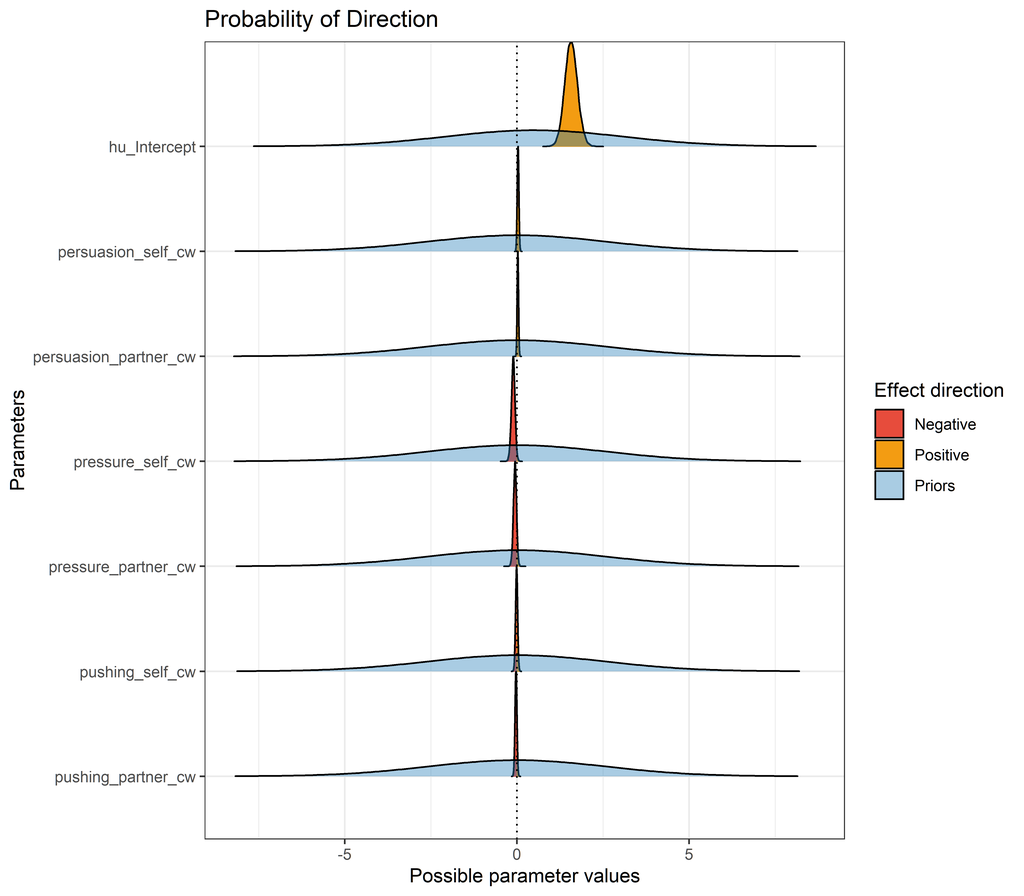

```r
# Plot continuous part of model

variable <- c(
  '(Intercept)',
  'b_persuasion_self_cw',
  'b_persuasion_partner_cw',
  'b_pressure_self_cw',
  'b_pressure_partner_cw',
  'b_pushing_self_cw',
  'b_pushing_partner_cw'
)


plot(
  bayestestR::p_direction(pa_sub, parameter = variable),
  priors = TRUE
) + theme_bw()
```

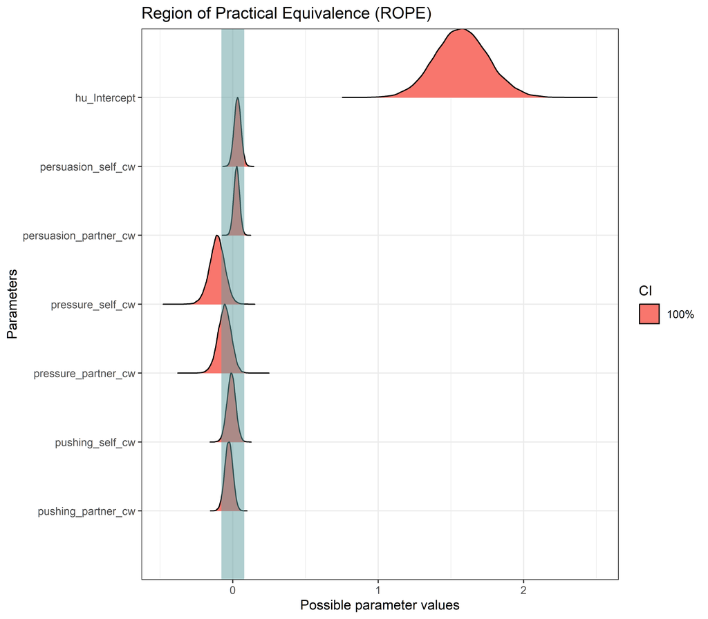

```r
plot(
  bayestestR::rope(
    pa_sub,
    parameter = variable,
    range = rope_range_continuous,
    verbose = F,
    ci = 1
  )
) + theme_bw()
```